# Jennifer Hightower

I'll check for outliers in other columns just for saftey

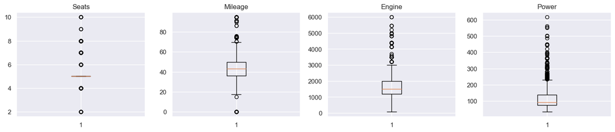

```python
numeric_columns = ['Seats', 'Mileage', 'Engine', 'Power']
plt.figure(figsize=(15, 12))

for i, variable in enumerate(numeric_columns):
    plt.subplot(4, 4, i + 1)
    plt.boxplot(df[variable], whis=1.5)
    plt.tight_layout()
    plt.title(variable)

plt.show()
```

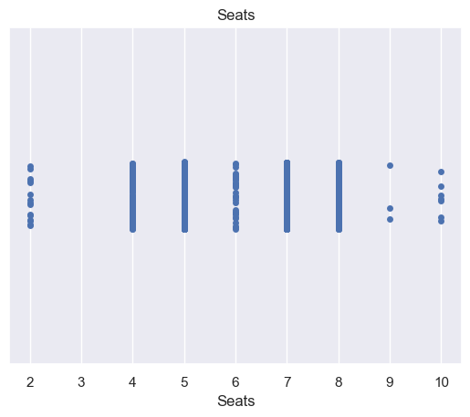

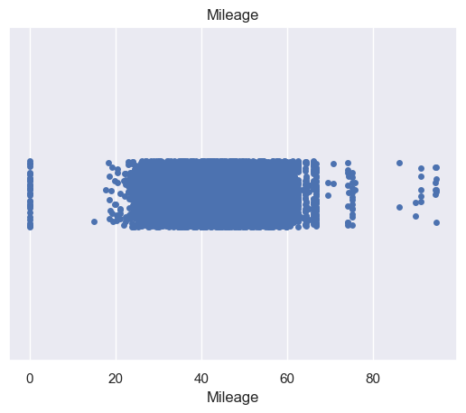

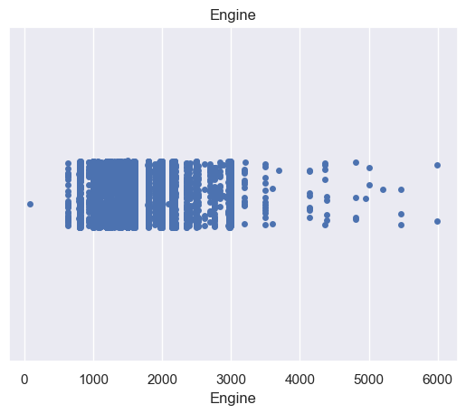

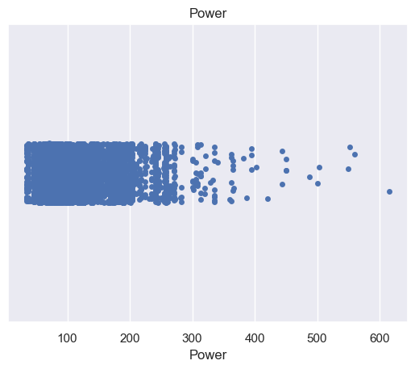

```python
for i, variable in enumerate(numeric_columns):
    # Create a new figure for each variable
    plt.figure(i)
    # Plot the stripplot on the new figure
    sns.stripplot(data=df, x=variable)
    # Set the title of the figure to the variable name
    plt.title(variable)
    # Show the figure
    plt.show()
```

```python
df.info()
```

```
<class 'pandas.core.frame.DataFrame'>
Int64Index: 7075 entries, 0 to 7252
Data columns (total 12 columns):
 #   Column        Non-Null Count  Dtype
---  ------        --------------  -----
 0   Location      7075 non-null   category
 1   Year          7075 non-null   int64
 2   Fuel_Type     7075 non-null   category
 3   Transmission  7075 non-null   category
 4   Owner_Type    7075 non-null   category
 5   Seats         7075 non-null   float64
 6   New_Price     7075 non-null   float64
 7   Price         7075 non-null   float64
 8   Car_Make      7075 non-null   category
 9   Mileage       7075 non-null   float64
 10  Engine        7075 non-null   float64
 11  Power         7075 non-null   float64
dtypes: category(5), float64(6), int64(1)
memory usage: 478.9 KB
```

```python
df.corr()
```

|  | Year | Seats | New_Price | Price | Mileage | Engine | Power |
| --- | --- | --- | --- | --- | --- | --- | --- |
| Year | 1.00 | 0.00 | -0.01 | 0.36 | 0.28 | -0.07 | 0.01 |
| Seats | 0.00 | 1.00 | 0.13 | 0.17 | -0.33 | 0.41 | 0.10 |
| New_Price | -0.01 | 0.13 | 1.00 | 0.75 | -0.51 | 0.77 | 0.83 |
| Price | 0.36 | 0.17 | 0.75 | 1.00 | -0.33 | 0.64 | 0.69 |
| Mileage | 0.28 | -0.33 | -0.51 | -0.33 | 1.00 | -0.62 | -0.53 |
| Engine | -0.07 | 0.41 | 0.77 | 0.64 | -0.62 | 1.00 | 0.86 |
| Power | 0.01 | 0.10 | 0.83 | 0.69 | -0.53 | 0.86 | 1.00 |

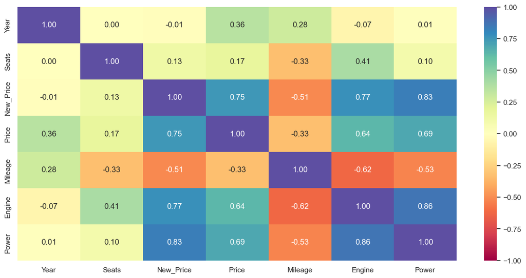

```python
# Check for correlation among numerical variables
num_var = ['Year','Seats','New_Price','Price', 'Mileage','Engine', 'Power']

corr = df[num_var].corr()

# plot the heatmap

plt.figure(figsize=(15, 7))
sns.heatmap(corr, annot=True, vmin=-1, vmax=1, fmt=".2f", cmap="Spectral")
plt.show()
```

```python
df.info()
```

```
<class 'pandas.core.frame.DataFrame'>
Int64Index: 7075 entries, 0 to 7252
Data columns (total 12 columns):
 #   Column        Non-Null Count  Dtype
---  ------        --------------  -----
 0   Location      7075 non-null   category
 1   Year          7075 non-null   int64
 2   Fuel_Type     7075 non-null   category
 3   Transmission  7075 non-null   category
 4   Owner_Type    7075 non-null   category
 5   Seats         7075 non-null   float64
 6   New_Price     7075 non-null   float64
 7   Price         7075 non-null   float64
 8   Car_Make      7075 non-null   category
 9   Mileage       7075 non-null   float64
 10  Engine        7075 non-null   float64
 11  Power         7075 non-null   float64
dtypes: category(5), float64(6), int64(1)
memory usage: 478.9 KB
```

```python
# Create correlation matrix
corr_mat = df.corr(method='pearson')

# Drop correlations where the variable names are the same
corr_mat = corr_mat.mask(np.tril(np.ones_like(corr_mat, dtype=bool)))

# Convert correlation matrix to 1-D Series and sort
sorted_mat = corr_mat.unstack().drop_duplicates().sort_values()

# Remove correlations with a value of 1 or null values
sorted_mat = sorted_mat[(sorted_mat != 1) & (~sorted_mat.isnull())]

print(sorted_mat)
```

```
Engine     Mileage     -0.62
Power      Mileage     -0.53
Mileage    New_Price   -0.51
           Price       -0.33
           Seats       -0.33
Engine     Year        -0.07
New_Price  Year        -0.01
Seats      Year         0.00
Power      Year         0.01
           Seats        0.10
New_Price  Seats        0.13
Price      Seats        0.17
Mileage    Year         0.28
Price      Year         0.36
Engine     Seats        0.41
           Price        0.64
Power      Price        0.69
Price      New_Price    0.75
Engine     New_Price    0.77
Power      New_Price    0.83
           Engine       0.86
dtype: float64
```

### Observations

Positive Correlations

1. There highest positive correlation is between Power and Engine at .86
2. New_price and Power are a close second with .83 positive correlation
3. Used Cars have the strongest correclation with New_Price, Power and Engine

Power, Engine and New_Price seem to have the highest correlations. I'll keep that in mind

1. Third strongest positive corelation is Engine and New_price, which isn't supprising since it's already been established that there is a strong correlation between Power and Engine, and Power and New_Price
2. Naturally Price has a somewhat strong positive correlation to Power and Engine at .69 and .64

Negative Correlations

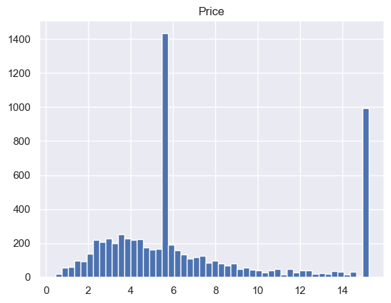

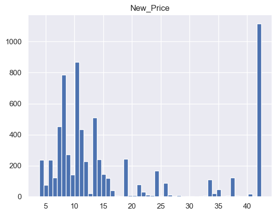

```python
cols = ['Price', 'New_Price']
for colname in cols:
    plt.hist(df[colname], bins=50)
    plt.title(colname)
    plt.show()
```

Both the Price and New_price are distributed rather chaotically.

I don't think normalizing the data will help because the chaotic distribution seems to still be caused by extreme values, even though now the outliers have been removed. I'll do a sanity check with the zscore.

```python
df['Price_zscore'] = zscore(df['Price'])
df['New_Price_zscore'] = zscore(df['New_Price'])
df.head()
```

|  | Location | Year | Fuel_Type | Transmission | Owner_Type | Seats | New_Price | Price | Car_Make | Mileage | Engine | Power | Price_zscore | New_Price_zscore |
| --- | --- | --- | --- | --- | --- | --- | --- | --- | --- | --- | --- | --- | --- | --- |
| 0 | Mumbai | 2010 | CNG | Manual | First | 5.00 | 5.51 | 1.75 | MARUTI | 75.14 | 998.00 | 58.16 | -1.23 | -0.93 |
| 1 | Pune | 2015 | Diesel | Manual | First | 5.00 | 16.06 | 12.50 | HYUNDAI | 46.27 | 1582.00 | 126.20 | 1.33 | -0.11 |
| 2 | Chennai | 2011 | Petrol | Manual | First | 5.00 | 8.61 | 4.50 | HONDA | 42.81 | 1199.00 | 88.70 | -0.57 | -0.69 |
| 3 | Chennai | 2012 | Diesel | Manual | First | 7.00 | 11.27 | 6.00 | MARUTI | 48.85 | 1248.00 | 88.76 | -0.22 | -0.48 |
| 4 | Coimbatore | 2013 | Diesel | Automatic | Second | 5.00 | 42.41 | 15.23 | AUDI | 35.75 | 1968.00 | 140.80 | 1.98 | 1.96 |

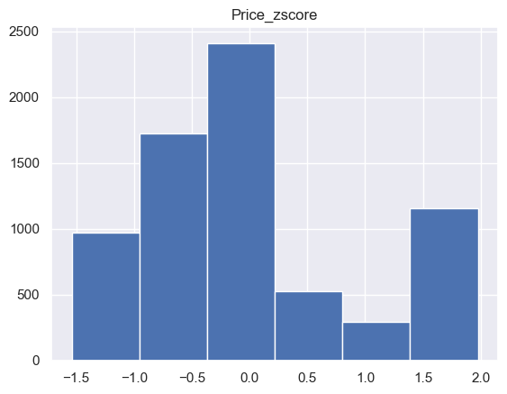

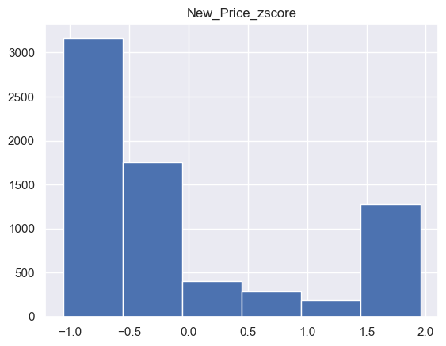

```python
cols = ['Price_zscore', 'New_Price_zscore']
for colname in cols:
    plt.hist(df[colname], bins=6)
    plt.title(colname)
    plt.show()
```

I think these Price values are legitamite, and don't need to be normalized.

The extreme values have been removed, and there are no outliers, but the distribution is bimodal which would certainly have an affect on our supervissed learning model

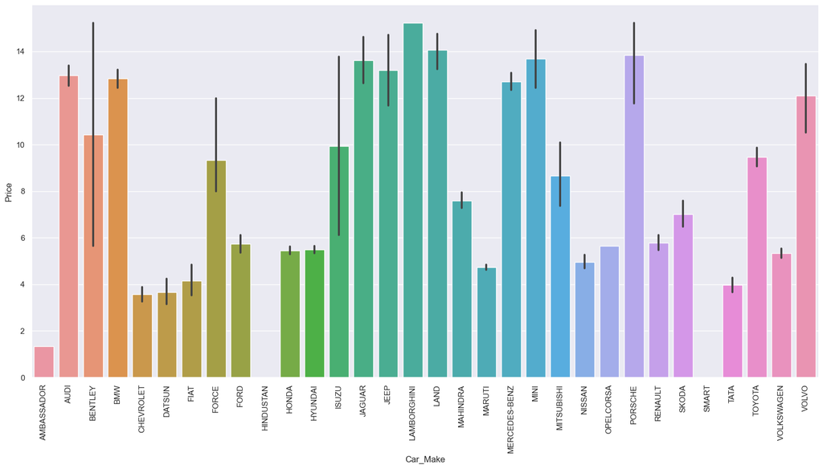

```python
##exploring the marketshare by Make of car for Used Cars

sns.catplot(x='Car_Make', y='Price', data=df, kind="bar", height=8, aspect=2)
plt.xticks(rotation=90)
plt.show()
```

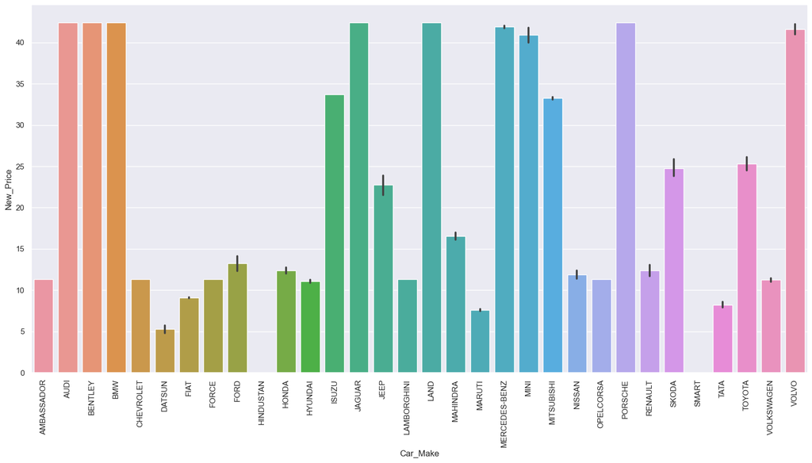

```python
#Marketshare for New Cars

sns.catplot(x='Car_Make', y='New_Price', data=df, kind="bar", height=8, aspect=2)
plt.xticks(rotation=90)
plt.show()
```

```python
df.groupby(['Car_Make'])['New_Price'].sum().sort_values(ascending=False)
```

```
Car_Make
MERCEDES-BENZ   15839.00
HYUNDAI         14222.18
BMW             12933.52
TOYOTA          12209.58
AUDI            12043.02
MARUTI          10655.26
HONDA            9092.45
MAHINDRA         5406.84
SKODA            4954.86
FORD             4524.39
VOLKSWAGEN       4189.73
LAND             2713.92
RENAULT          2099.49
JAGUAR           2035.44
TATA             1839.36
CHEVROLET        1695.00
NISSAN           1342.92
MINI             1268.54
MITSUBISHI       1196.92
VOLVO            1164.82
PORSCHE           720.88
JEEP              432.18
FIAT              290.08
ISUZU             168.40
DATSUN             89.44
BENTLEY            84.81
FORCE              33.90
LAMBORGHINI        11.30
OPELCORSA          11.30
AMBASSADOR         11.30
HINDUSTAN           0.00
SMART               0.00
Name: New_Price, dtype: float64
```

For New_Price Marketvalue, the top 5 preformers are: Mercedes-Benz, Hyundai, BMW, Toyota, and Audi

```python
df.groupby(['Car_Make'])['Price'].sum().sort_values(ascending=False)
```

```
Car_Make
HYUNDAI         7067.35
MARUTI          6643.53
MERCEDES-BENZ   4803.03
TOYOTA          4562.47
HONDA           4006.53
BMW             3912.81
AUDI            3682.17
MAHINDRA        2485.13
VOLKSWAGEN      1987.12
FORD            1960.37
SKODA           1402.19
RENAULT          981.86
LAND             900.53
TATA             888.43
JAGUAR           654.12
NISSAN           561.20
CHEVROLET        536.08
MINI             424.05
VOLVO            339.12
MITSUBISHI       312.22
JEEP             250.71
PORSCHE          235.31
FIAT             132.88
DATSUN            62.20
ISUZU             49.73
FORCE             28.00
BENTLEY           20.87
LAMBORGHINI       15.23
OPELCORSA          5.64
AMBASSADOR         1.35
HINDUSTAN          0.00
SMART              0.00
Name: Price, dtype: float64
```

For Used Car Marketplace the top 5 performers are: Hyundai, Maruti, Mercedes-Benz, Toyota, and Honda

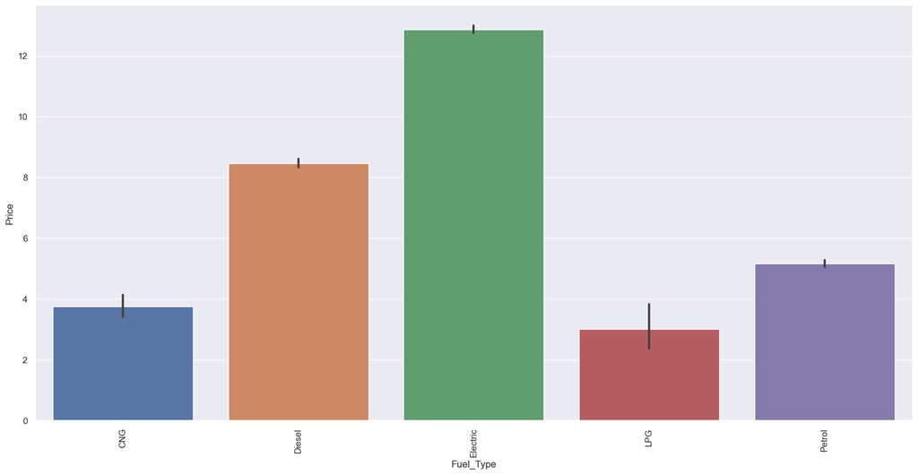

```python
##exploring the marketshare by Fuel Type for Used Cars

sns.catplot(x='Fuel_Type', y='Price', data=df, kind="bar", height=8, aspect=2)
plt.xticks(rotation=90)
plt.show()
```

```python
df.groupby(['Fuel_Type'])[['Price']].sum().sort_values(by='Price', ascending=False)
```

| Fuel_Type | Price |
| --- | --- |
| Diesel | 32002.47 |
| Petrol | 16618.27 |
| CNG | 229.58 |
| LPG | 36.15 |
| Electric | 25.75 |

```python
df.groupby(['Fuel_Type'])[['Price']].min().sort_values(by='Price', ascending=False)
```

| Fuel_Type | Price |
| --- | --- |
| Electric | 12.75 |
| LPG | 1.45 |
| CNG | 1.40 |
| Diesel | 0.60 |
| Petrol | 0.44 |

```python
df.groupby(['Fuel_Type'])[['Price']].max().sort_values(by='Price', ascending=False)
```

| Fuel_Type | Price |
| --- | --- |
| Diesel | 15.23 |
| Petrol | 15.23 |
| Electric | 13.00 |
| CNG | 8.35 |
| LPG | 5.64 |

So Electric looks like it is the most expensive but the least popular as far as marketshare.

Diesel takes the lead being the most opular and Petrol is a distant second.

I see that Diesel and Petrol both have the highest and lowest per price point and I bet that is becasue of the different types of fuels in that group like Regular, Unleaded, Supreme etc. The prices between those can vary.

```python
df.Fuel_Type.unique()
```

```
['CNG', 'Diesel', 'Petrol', 'LPG', 'Electric']
Categories (5, object): ['CNG', 'Diesel', 'Electric', 'LPG', 'Petrol']
```

Just out of curiosity I wanted to see the breakdown of Fuel_Type my Car Brand

```python
cng_df = df[df['Fuel_Type'] == 'CNG']
diesel_df = df[df['Fuel_Type'] == 'Diesel']
petrol_df = df[df['Fuel_Type'] == 'Petrol']
lpg_df = df[df['Fuel_Type'] == 'LPG']
electric_df = df[df['Fuel_Type'] == 'Electric']
```

```python
cng = cng_df.groupby(['Car_Make'])[['Price']].sum()
cng = cng[cng['Price'] > 0]
cng = cng.sort_values(by='Price', ascending=False)

# Print the results
print(cng)
```

```
          Price
Car_Make
MARUTI   202.24
HYUNDAI   17.49
TATA       6.50
TOYOTA     3.35
```

```python
diesel = diesel_df.groupby(['Car_Make'])[['Price']].sum()
diesel = diesel[diesel['Price'] > 0]
diesel = diesel.sort_values(by='Price', ascending=False)

# Print the results
print(diesel)
```

```
                Price
Car_Make
TOYOTA        3777.84
MERCEDES-BENZ 3723.62
BMW           3550.50
AUDI          3425.70
MARUTI        3131.98
HYUNDAI       2862.18
MAHINDRA      2411.02
FORD          1387.48
VOLKSWAGEN    1125.47
HONDA          943.15
LAND           900.53
RENAULT        775.99
SKODA          772.80
JAGUAR         581.94
TATA           566.74
NISSAN         348.18
VOLVO          339.12
CHEVROLET      315.24
MITSUBISHI     289.59
JEEP           229.85
MINI           214.85
PORSCHE        173.12
FIAT            76.52
ISUZU           49.73
FORCE           28.00
AMBASSADOR       1.35
```

```python
petrol = petrol_df.groupby(['Car_Make'])[['Price']].sum()
petrol = petrol[petrol['Price'] > 0]
petrol = petrol.sort_values(by='Price', ascending=False)

# Print the results
print(petrol)
```

```
                Price
Car_Make
HYUNDAI       4168.90
MARUTI        3291.95
HONDA         3063.38
MERCEDES-BENZ 1079.41
VOLKSWAGEN     861.65
TOYOTA         768.52
SKODA          629.39
FORD           572.88
BMW            362.31
TATA           315.20
AUDI           256.47
CHEVROLET      220.84
NISSAN         213.02
MINI           209.21
RENAULT        205.87
JAGUAR          72.18
DATSUN          62.20
PORSCHE         62.20
MAHINDRA        61.11
FIAT            56.36
MITSUBISHI      22.63
BENTLEY         20.87
JEEP            20.87
LAMBORGHINI     15.23
OPELCORSA        5.64
```

```python
lpg = lpg_df.groupby(['Car_Make'])[['Price']].sum()
lpg = lpg[lpg['Price'] > 0]
lpg = lpg.sort_values(by='Price', ascending=False)

# Print the results
print(lpg)
```

```
          Price
Car_Make
HYUNDAI   18.79
MARUTI    17.36
```

```python
electric = electric_df.groupby(['Car_Make'])[['Price']].sum()
electric = electric[electric['Price'] > 0]
electric = electric.sort_values(by='Price', ascending=False)

# Print the results
print(electric)
```

```
          Price
Car_Make
MAHINDRA  13.00
TOYOTA    12.75
```

It's clear to see that most of the car Brands use Diesel or Petrol and only a fraction of those Brands use CNG, LPG or Electric

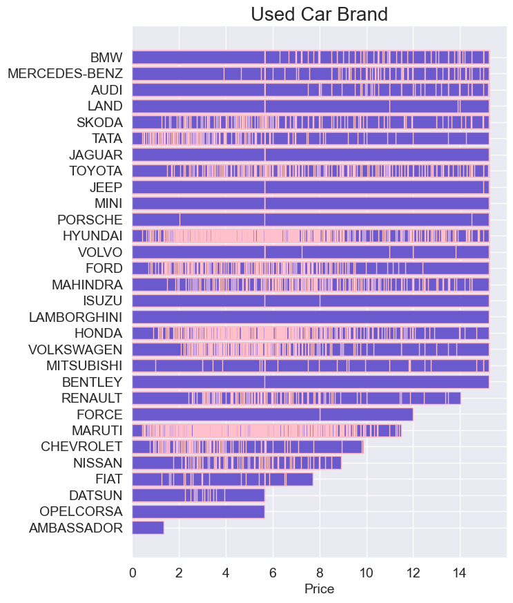

```python
df = df.sort_values('Price', ascending=False)

plt.figure(figsize=(7, 10))
plt.barh(df['Car_Make'], df['Price'], color='slateblue', edgecolor='pink')
plt.gca().invert_yaxis()
plt.title('Used Car Brand', fontsize=20)
plt.xlabel('Price', fontsize=14)
plt.xticks(fontsize=14)
plt.yticks(fontsize=14)
plt.tick_params(left=False)
sns.despine(left=True)
plt.show()
```

The Jeep, Porche, Mini, Jaguar, Bentley, Lamnborghini and Isuzu do not seem to vary much in terms of price.

The Brands that do vary greatly are Hyundai, Ford, Mihindra, Honda, Volkswagon, and Maruti.

It looks like the Datsun, OpelCorsa and Ambassador are the lowest prised Used Car brands

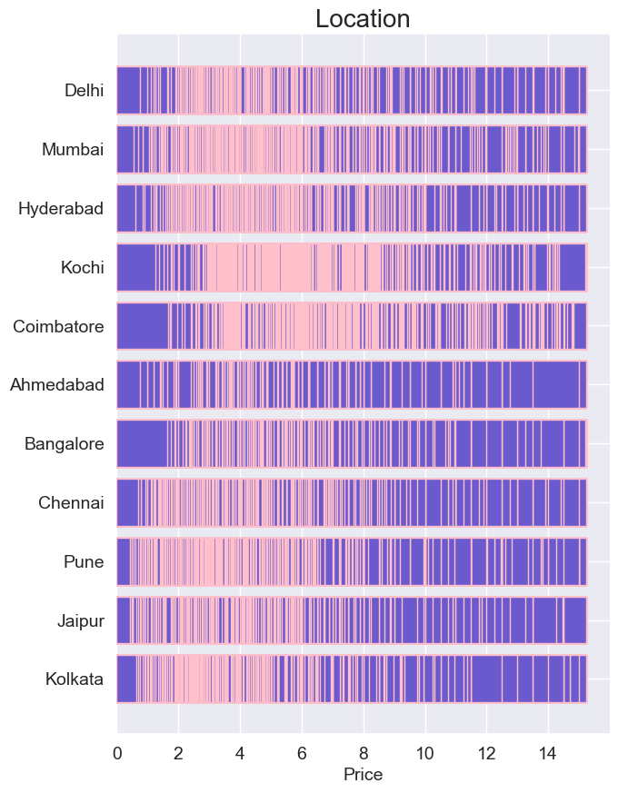

```python
plt.figure(figsize=(7, 10))
plt.barh(df['Location'], df['Price'], color='slateblue', edgecolor='pink')
plt.gca().invert_yaxis()
plt.title('Location', fontsize=20)
plt.xlabel('Price', fontsize=14)
plt.xticks(fontsize=14)
plt.yticks(fontsize=14)
plt.tick_params(left=False)
sns.despine(left=True)
plt.show()
```

The Prices seem to vary in a normally distributed way for all the locations. It does seem like there is a slight Right skewness for most which probably indicates the highest the price of the vehicle, the price points are less varied for Used Cars.

```python
df.head()
```

|  | Location | Year | Fuel_Type | Transmission | Owner_Type | Seats | New_Price | Price | Car_Make | Mileage | Engine | Power | Price_zscore | New_Price_zscore |
| --- | --- | --- | --- | --- | --- | --- | --- | --- | --- | --- | --- | --- | --- | --- |
| 3632 | Delhi | 2011 | Diesel | Automatic | First | 4.00 | 42.41 | 15.23 | BMW | 26.34 | 2993.00 | 241.00 | 1.98 | 1.96 |
| 2509 | Mumbai | 2018 | Diesel | Automatic | First | 5.00 | 42.41 | 15.23 | MERCEDES-BENZ | 37.87 | 1950.00 | 194.00 | 1.98 | 1.96 |
| 2543 | Hyderabad | 2013 | Diesel | Automatic | First | 5.00 | 42.41 | 15.23 | BMW | 31.05 | 1995.00 | 170.00 | 1.98 | 1.96 |
| 2541 | Kochi | 2018 | Diesel | Automatic | First | 5.00 | 42.41 | 15.23 | MERCEDES-BENZ | 30.58 | 2987.00 | 265.00 | 1.98 | 1.96 |
| 2537 | Coimbatore | 2016 | Diesel | Automatic | Second | 7.00 | 42.41 | 15.23 | AUDI | 28.39 | 2967.00 | 241.40 | 1.98 | 1.96 |

```python
df.drop(['Price_zscore'], axis=1,inplace=True)
df.drop(['New_Price_zscore'], axis=1,inplace=True)
```

```python
df.head()
```

|  | Location | Year | Fuel_Type | Transmission | Owner_Type | Seats | New_Price | Price | Car_Make | Mileage | Engine | Power |
| --- | --- | --- | --- | --- | --- | --- | --- | --- | --- | --- | --- | --- |
| 3632 | Delhi | 2011 | Diesel | Automatic | First | 4.00 | 42.41 | 15.23 | BMW | 26.34 | 2993.00 | 241.00 |
| 2509 | Mumbai | 2018 | Diesel | Automatic | First | 5.00 | 42.41 | 15.23 | MERCEDES-BENZ | 37.87 | 1950.00 | 194.00 |
| 2543 | Hyderabad | 2013 | Diesel | Automatic | First | 5.00 | 42.41 | 15.23 | BMW | 31.05 | 1995.00 | 170.00 |
| 2541 | Kochi | 2018 | Diesel | Automatic | First | 5.00 | 42.41 | 15.23 | MERCEDES-BENZ | 30.58 | 2987.00 | 265.00 |
| 2537 | Coimbatore | 2016 | Diesel | Automatic | Second | 7.00 | 42.41 | 15.23 | AUDI | 28.39 | 2967.00 | 241.40 |

```python
df = pd.get_dummies(df
               ,columns = ['Fuel_Type', 'Transmission', 'Owner_Type', 'Car_Make', 'Location']
               ,drop_first = True
               )
df.head()
```

[output not shown]

|  | Year | Seats | New_Price | Price | Mileage | Engine | Power | Fuel_Type_Diesel | Fuel_Type_Electric | Fuel_Type_LPG | ... | Location_Bangalore | Location_Chennai | Location_Coimbatore | Location_Delhi | Location_Hyderabad | Location_Jaipur | Location_Kochi | Location_Kolkata | Location_Mumbai | Location_Pune |
| --- | --- | --- | --- | --- | --- | --- | --- | --- | --- | --- | --- | --- | --- | --- | --- | --- | --- | --- | --- | --- | --- |
| 3632 | 2011 | 4.00 | 42.41 | 15.23 | 26.34 | 2993.00 | 241.00 | 1 | 0 | 0 | ... | 0 | 0 | 0 | 1 | 0 | 0 | 0 | 0 | 0 | 0 |
| 2509 | 2018 | 5.00 | 42.41 | 15.23 | 37.87 | 1950.00 | 194.00 | 1 | 0 | 0 | ... | 0 | 0 | 0 | 0 | 0 | 0 | 0 | 0 | 1 | 0 |
| 2543 | 2013 | 5.00 | 42.41 | 15.23 | 31.05 | 1995.00 | 170.00 | 1 | 0 | 0 | ... | 0 | 0 | 0 | 0 | 1 | 0 | 0 | 0 | 0 | 0 |
| 2541 | 2018 | 5.00 | 42.41 | 15.23 | 30.58 | 2987.00 | 265.00 | 1 | 0 | 0 | ... | 0 | 0 | 0 | 0 | 0 | 0 | 1 | 0 | 0 | 0 |
| 2537 | 2016 | 7.00 | 42.41 | 15.23 | 28.39 | 2967.00 | 241.40 | 1 | 0 | 0 | ... | 0 | 0 | 1 | 0 | 0 | 0 | 0 | 0 | 0 | 0 |

5 rows × 56 columns

```python
df.info()
```

```
<class 'pandas.core.frame.DataFrame'>
Int64Index: 7075 entries, 3632 to 1713
Data columns (total 56 columns):
 #   Column                     Non-Null Count  Dtype
---  ------                     --------------  -----
 0   Year                       7075 non-null   int64
 1   Seats                      7075 non-null   float64
 2   New_Price                  7075 non-null   float64
 3   Price                      7075 non-null   float64
 4   Mileage                    7075 non-null   float64
 5   Engine                     7075 non-null   float64
 6   Power                      7075 non-null   float64
 7   Fuel_Type_Diesel           7075 non-null   uint8
 8   Fuel_Type_Electric         7075 non-null   uint8
 9   Fuel_Type_LPG              7075 non-null   uint8
```

[output cut: 48 more lines]

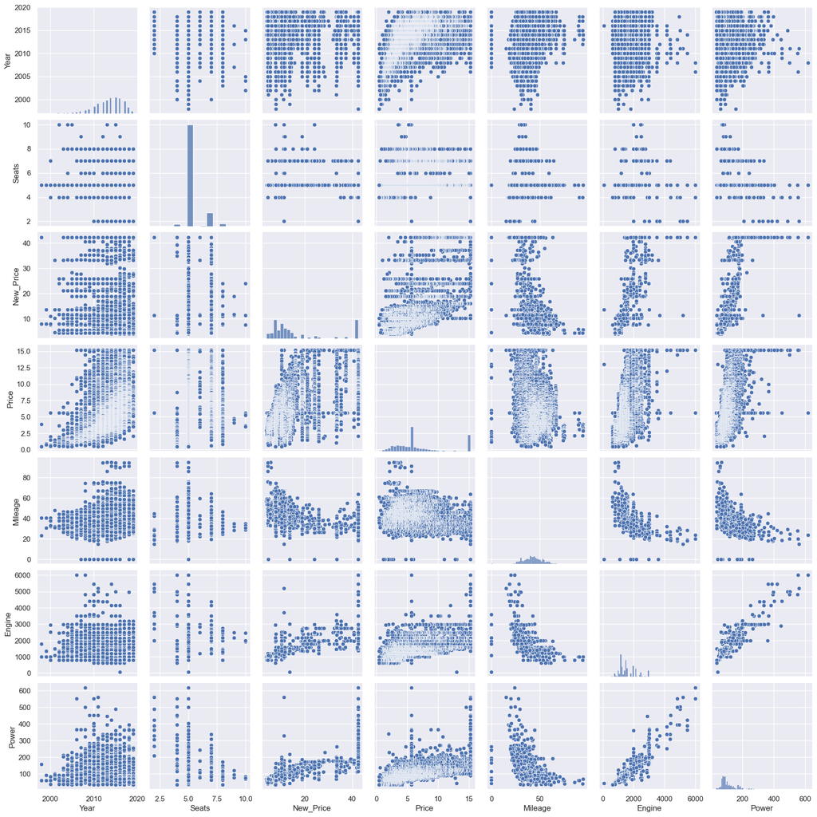

```python
#Pairplot
sns.pairplot(data=df[['Year','Seats','New_Price','Price',
                      'Mileage','Engine', 'Power']])
```

```python
import pandas as pd


# Compute the correlation matrix
corr_matrix = df.corr()

# Filter out variables with correlation coefficients above 50% or below -50%
high_corr_vars = corr_matrix[abs(corr_matrix) > 0.2].stack().reset_index()
high_corr_vars = high_corr_vars[high_corr_vars['level_0'] != high_corr_vars['level_1']]
high_corr_vars = high_corr_vars.drop_duplicates(subset=[0])
high_corr_vars.columns = ['Variable 1', 'Variable 2', 'Correlation']
high_corr_vars = high_corr_vars.sort_values(by='Correlation', ascending=False)

corr_list = high_corr_vars[['Variable 1', 'Variable 2']].values.flatten().tolist()
corr_list = list(set(corr_list))

#Remove Price because that is what we are going to use to predict
corr_list.remove('Price')

# Print the variables that have correlation coefficients above 20% or below -20%
print(corr_list)
```

```
['Car_Make_MARUTI', 'Car_Make_HYUNDAI', 'Owner_Type_Third', 'New_Price', 'Location_Kochi', 'Engine', 'Car_Make_HONDA', 'Mileage', 'Fuel_Type_Diesel', 'Transmission_Manual', 'Seats', 'Car_Make_TOYOTA', 'Car_Make_AUDI', 'Power', 'Fuel_Type_Petrol', 'Car_Make_MERCEDES-BENZ', 'Year', 'Owner_Type_Second'…
```